# R代码合集

Fan

2020年4月12日

## 简介

本文档记录一些实用的R代码

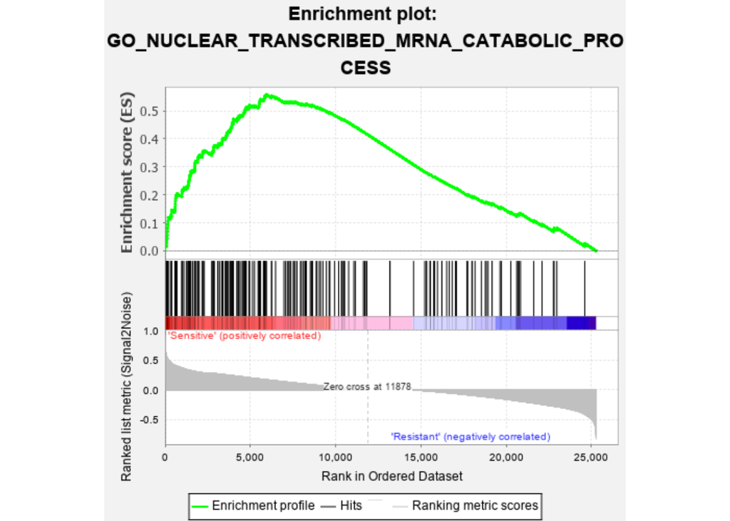

```r
library(EBImage)
pic = readImage("C:\\Users\\dell\\gsea_home\\output\\apr14\\my_analysis.Gsea.1586853742423\\enplot_GO_NUCLEAR_TRANSCRIBED_MRNA_CATABOLIC_PROCESS_265.png")
display(pic)
```

## 基本操作

```r
library(dplyr)
library(purrr)
library(kableExtra)
# extended summary for tibble
my_summary_tibble<-function(data,fun){ return( map(data,fun) %>% unlist() %>% as.vector() ) }

# transpose for tibble
my_t_tibble<-function(data,name,id){
  temp<-t(data[,-which(colnames(data)==name)])
  colnames(temp)<-data[name] %>% unlist() %>% as.vector()
  return(as_tibble(temp,rownames=id))
}

xx<-tibble(name=letters[1:5],x=c(1:5),y=rnorm(5,mean=0,sd=1),z=sample(5,5))
xx %>% modify_at(c("y"),function(x) round(x,2)) %>%
  kable() %>% kable_styling(bootstrap_options = "striped", full_width = F)
```

| name | x | y | z |
| --- | --- | --- | --- |
| a | 1 | 1.55 | 5 |
| b | 2 | 0.50 | 3 |
| c | 3 | -0.12 | 4 |
| d | 4 | -0.21 | 1 |
| e | 5 | -0.62 | 2 |

```r
xx.summary<-tibble(id=colnames(xx)[-1],
                   mean=my_summary_tibble(xx[,-1],mean),
                   sd=my_summary_tibble(xx[,-1],sd),
                   sum=my_summary_tibble(xx[,-1],sum))
xx.summary %>% modify_at(c(-1),function(x) round(x,2)) %>%
  kable() %>% kable_styling(bootstrap_options = "striped", full_width = F)
```

| id | mean | sd | sum |
| --- | --- | --- | --- |
| x | 3.00 | 1.58 | 15.00 |
| y | 0.22 | 0.84 | 1.09 |
| z | 3.00 | 1.58 | 15.00 |

```r
xx.transpose<-my_t_tibble(xx,name="name",id="id")
xx.transpose%>% modify_at(c(-1),function(x) round(x,2)) %>%
  kable() %>% kable_styling(bootstrap_options = "striped", full_width = F)
```

| id | a | b | c | d | e |
| --- | --- | --- | --- | --- | --- |
| x | 1.00 | 2.0 | 3.00 | 4.00 | 5.00 |
| y | 1.55 | 0.5 | -0.12 | -0.21 | -0.62 |
| z | 5.00 | 3.0 | 4.00 | 1.00 | 2.00 |

```r
xx.summary.row<-tibble(id=colnames(xx.transpose)[-1],
                       mean=my_summary_tibble(xx.transpose[,-1],mean),
                       sd=my_summary_tibble(xx.transpose[,-1],sd),
                       sum=my_summary_tibble(xx.transpose[,-1],sum))
xx.summary.row %>% modify_at(c(-1),function(x) round(x,2)) %>%
  kable() %>% kable_styling(bootstrap_options = "striped", full_width = F)
```

| id | mean | sd | sum |
| --- | --- | --- | --- |
| a | 2.52 | 2.17 | 7.55 |
| b | 1.83 | 1.26 | 5.50 |
| c | 2.29 | 2.15 | 6.88 |
| d | 1.60 | 2.17 | 4.79 |
| e | 2.13 | 2.81 | 6.38 |

## 可视化

### 每个病例的参数概览图（包括分类变量）

本来打算使用空矩阵构建热图来完成此需求，然而在空矩阵的情况下，图例放在下方会出现图例位置过度上移， 导致图片的重叠，尝试了很久后决定采用隐藏矩阵值且调整padding达到要求（padding参数挽救了这个“轮子”）

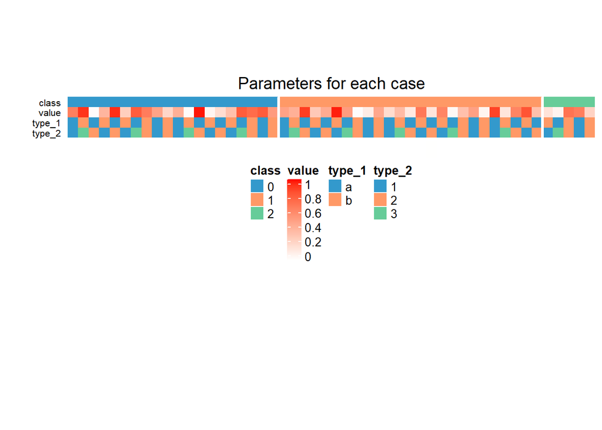

```r
library(ComplexHeatmap)
library(circlize)
data_mat = matrix(rnorm(50,0,1), 1, 50)
colors = colorRamp2(c(0, 1000), c("white", "red"))
use_colors = c("#3399CC","#FF9966","#66CC99","white","66CCCC")
gap_wd = 3
anno_data = data.frame(class = c(rep("0",20),rep("1",25),rep("2",5)),
                       value = runif(50),
                       type_1 = rep(letters[1:2], 25),
                       type_2 = rep(c("1","3","2","1","2"),10))
anno_color = list(class = c("0" = use_colors[1], "1" = use_colors[2],"2" = use_colors[3]),
                  value = colorRamp2(c(0, 1), c("white", "red")),
                  type_1 = c("a" = use_colors[1], "b" = use_colors[2]),
                  type_2 = c("1" = use_colors[1], "2" = use_colors[2], "3"=use_colors[3]))
anno_params = list(legend_height = unit(1, "cm"))
ha = HeatmapAnnotation(df = anno_data,
                       col = anno_color,
                       annotation_legend_param = anno_params)
colnames(data_mat) = rep("A",50)
heatmap_1 = Heatmap(data_mat, col = colors, column_title = "Parameters for each case",
                    top_annotation = ha, top_annotation_height = unit(12, "mm"),
                    cluster_rows = FALSE, cluster_columns = FALSE,
                    show_heatmap_legend = F,
                    show_row_names = FALSE, show_column_names = FALSE)
draw(heatmap_1,annotation_legend_side = "bottom"
     ,padding = unit(c(50, 20, 20, 2), "mm"))
annotations = c("class","value","type_1","type_2")
for (element in annotations){
  decorate_annotation(element, {grid.text(element, unit(-2, "mm"), just = "right", gp = gpar(fontsize=8))
    grid.lines(c(0.4, 0.4), unit(c(0, 1), "native"), gp = gpar(col = use_colors[4], lwd = gap_wd))
    grid.lines(c(0.9, 0.9), unit(c(0, 1), "native"), gp = gpar(col = use_colors[4], lwd = gap_wd))})
}
```

## 生存分析

### 计算iAUC

主要是使用R包risksetROC，计算的核心代码如下：

```r
library(survival)
library(risksetROC)
library(survivalROC) # load the mayo data
data(mayo)
nobs <- NROW(mayo)
survival.time <-mayo$time/365
survival.status <- mayo$censor
M<-mayo$mayoscore4
## first find the estimated survival probabilities at unique failure times
surv.prob <- unique(survfit(Surv(survival.time,survival.status)~1)$surv)

fit0 <- coxph( Surv(survival.time,survival.status)
               ~ M, na.action=na.omit )
eta <- fit0$linear.predictor
model.score <- eta
utimes <- unique( survival.time[ survival.status == 1 ] )
utimes <- utimes[ order(utimes) ]
## find AUC at unique failure times
AUC <- rep( NA, length(utimes) )
for( j in 1:length(utimes) )
{
  out <- CoxWeights( eta, survival.time, survival.status,utimes[j])
  AUC[j] <- out$AUC
}
## integrated AUC to get concordance measure
iAUC <- IntegrateAUC( AUC, utimes, surv.prob, tmax=365 )
iAUC
```

```
## [1] 0.7269898
```

### 时间依赖ROC的绘制

主要使用R包timeROC和ggplot2，绘制的核心代码如下：

```r
library(timeROC)
library(ggplot2)
library(survivalROC) # load the mayo data
data(mayo)
survival.time <-mayo$time/365
survival.status <- mayo$censor
M<-mayo$mayoscore4
ROC.1<-timeROC(T=survival.time,
               delta=survival.status,marker=M,
               cause=1,weighting="marginal",
               times=quantile(survival.time,probs=seq(0.2,0.8,0.02)),
               iid=TRUE)
ROC.1
```

[output not shown]

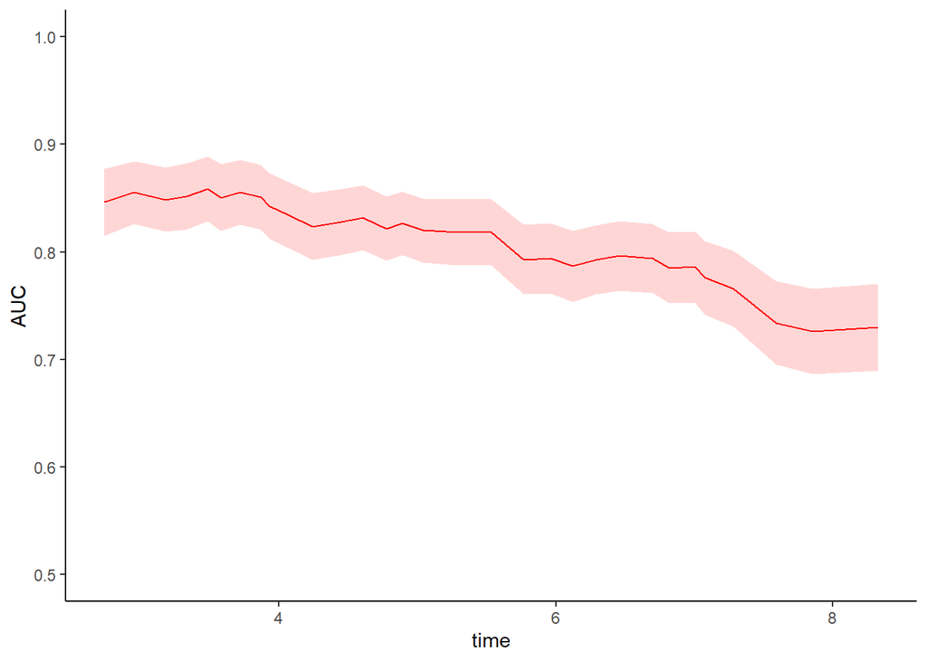

```r
time_AUC<-data.frame(time=ROC.1$times,
                     AUC=ROC.1$AUC,
                     sd=ROC.1$inference$vect_sd_1,
                     AUC_upper=ROC.1$AUC+ROC.1$inference$vect_sd_1,
                     AUC_lower=ROC.1$AUC-ROC.1$inference$vect_sd_1)

ggplot(time_AUC,aes(x=time,y=AUC))+
  geom_line(colour='red')+
  scale_y_continuous(limits = c(0.5,1))+
  geom_ribbon(aes(ymin = AUC_lower,ymax = AUC_upper),alpha = 0.16,fill="red")+
  theme(panel.grid.major =element_blank(),
        panel.grid.minor = element_blank(),
        panel.background = element_blank(),
        axis.line = element_line(colour = "black"))
```

### 特定时间点ROC曲线绘制

主要使用R包survivalROC和plotROC以及ggplot2，当然也可以使用timeROC的结果拿到特定时间点的ROC曲线数据进行绘制。绘制的核心代码如下：

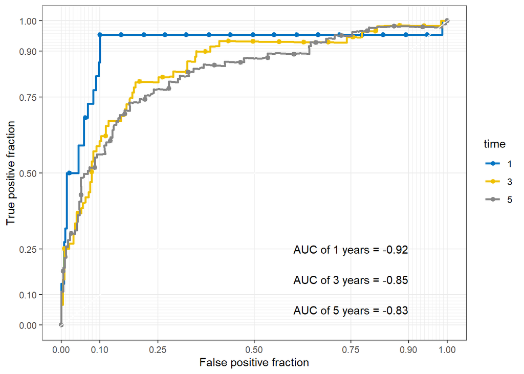

```r
library(survivalROC)
library(survival)
library(ggplot2)
library(plotROC)
data(mayo)
nobs <- NROW(mayo)
survT <-mayo$time/365
cens <- mayo$censor
M<-mayo$mayoscore4

### time: 1,3,5
sroc <- lapply(c(1, 3, 5), function(t){
  stroc <- survivalROC(Stime = survT, status = cens, marker = M,
                       predict.time = t,
                       method = "KM"  ## KM法
                       # method = "NNE", span = .25 * 350^(-.2) ## NE法
                       )
  data.frame(TPF = stroc[["TP"]], FPF = stroc[["FP"]],
             c = stroc[["cut.values"]],
             time = rep(stroc[["predict.time"]], length(stroc[["FP"]])))
})

## combine data
sroclong <- do.call(rbind, sroc)
sroclong$time<-factor(sroclong$time)

## plot ROC
pROC<-ggplot(sroclong, aes(x = FPF, y = TPF, label = c, color = time)) +
  geom_roc(labels = FALSE, stat = "identity",n.cuts = 20) +
  style_roc()+
  ggsci::scale_color_jco()

pROC+annotate("text",x = .75, y = .25, ## position of text
           label = paste("AUC of 1 years =", round(calc_auc(pROC)$AUC[1], 2))) +
     annotate("text",x = .75, y = .15, ## position of text
            label=paste("AUC of 3 years =", round(calc_auc(pROC)$AUC[2], 2)))+
     annotate("text",x = .75, y = .05, ## position of text
            label=paste("AUC of 5 years =", round(calc_auc(pROC)$AUC[3], 2)))
```

### 生存分析三联图

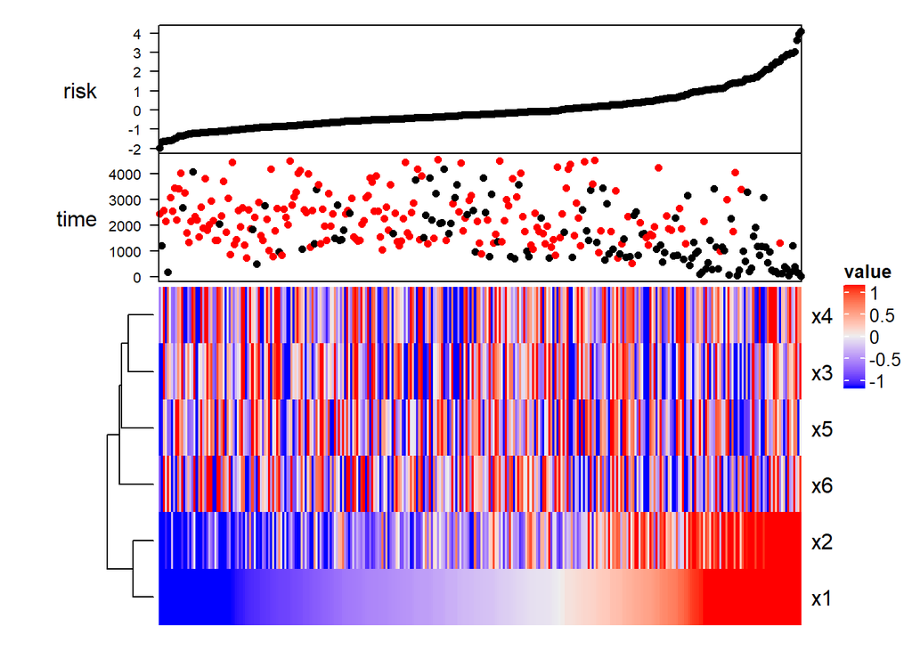

```r
library(survival)
library(survivalROC)
library(dplyr)
library(ggplot2)
library(ComplexHeatmap)
data(mayo)
nobs <- NROW(mayo)
survival.time <-mayo$time
survival.status <- mayo$censor
M<-mayo$mayoscore4
x3=rnorm(length(M),6,1)
x4=rnorm(length(M),0,1)+x3
x5=rnorm(length(M),0,1)+x3
x6=rnorm(length(M),0,1)+x3
surv.prob <- unique(survfit(Surv(survival.time,survival.status)~1)$surv)

fit0 <- coxph( Surv(survival.time,survival.status)
               ~ M, na.action=na.omit )
fp <- fit0$linear.predictor
sur_dat<-tibble(fp=as.numeric(fp),
                time=survival.time,
                event=survival.status,
                x1=mayo$mayoscore4,
                x2=mayo$mayoscore5,
                x3=x3,
                x4=x4,
                x5=x5,
                x6=x6) %>%
  arrange(fp)
sur_dat$patientid<-1:length(fp)
sur_dat$event=ifelse(sur_dat$event==0,'alive','death')
sur_dat$event=factor(sur_dat$event,levels = c("death","alive"))
exp_dat=sur_dat[,c(4:9)]
tmp=t(scale(exp_dat))
tmp[tmp > 1] = 1
tmp[tmp < -1] = -1
ha = HeatmapAnnotation(risk = anno_points(sur_dat$fp,axis = TRUE),
                       time = anno_points(sur_dat$time, axis = TRUE,
                                          pch = 16, default.unit = "native",
                                          gp = gpar(col=sur_dat$event)))
heatmap_1<-Heatmap(tmp, name = "value", cluster_columns = FALSE,
                   top_annotation = ha, top_annotation_height = unit(50, "mm"),
                   bottom_annotation_height = unit(3, "cm"))
draw(heatmap_1,padding = unit(c(5, 20, 5, 2), "mm"))
annotations = c("risk","time")
for (element in annotations){
  decorate_annotation(element,
                      {grid.text(element, unit(-12, "mm"), just = "right", gp = gpar(fontsize=12))})
}
```

## 建模相关可视化

### 绘制ROC

**使用pROC包绘制的核心代码如下：**

```r
library(pROC)
data(aSAH)
fit.model <- glm(outcome ~ s100b + ndka,
                 data=aSAH, family=binomial())
y_predict<-predict(fit.model,newdata=aSAH,type='response')
modelroc_1<-roc(aSAH$outcome,y_predict)
auc(modelroc_1)
```

```
## Area under the curve: 0.7818
```

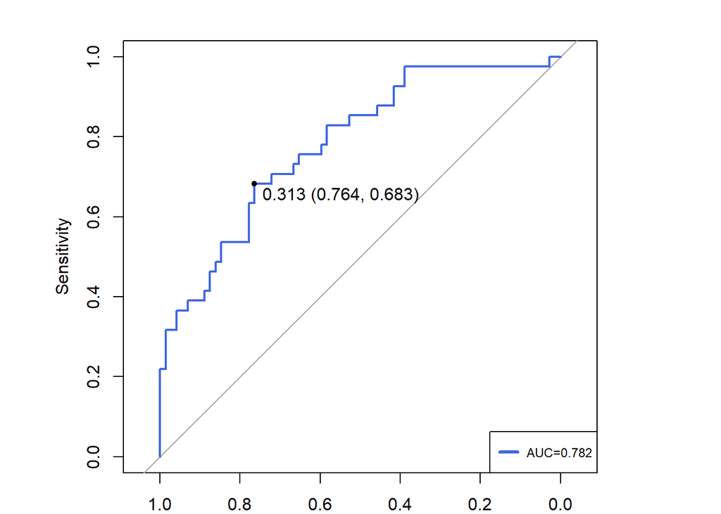

```r
plot(modelroc_1,col="royalblue",mar=c(2, 6, 2, 6),print.thres="best")
legend("bottomright", col=c("royalblue"), lwd=3, cex=0.75,
       legend=c(paste("AUC=",round(auc(modelroc_1),3),sep="")))
```

**ROC曲线的对比：**

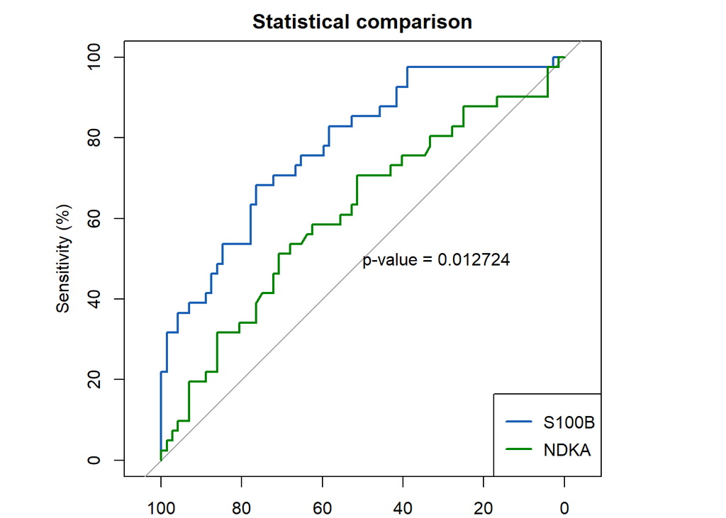

```r
rocobj1 <- plot.roc(aSAH$outcome, y_predict, mar=c(2, 6, 2, 6),
                    main="Statistical comparison", percent=TRUE, col="#1c61b6")
rocobj2 <- lines.roc(aSAH$outcome, aSAH$ndka, percent=TRUE, col="#008600")
testobj <- roc.test(rocobj1, rocobj2)
text(50, 50, labels=paste("p-value =", format.pval(testobj$p.value)), adj=c(0, .5))
legend("bottomright", legend=c("S100B", "NDKA"), col=c("#1c61b6", "#008600"), lwd=2)
```

**Partial AUC：**

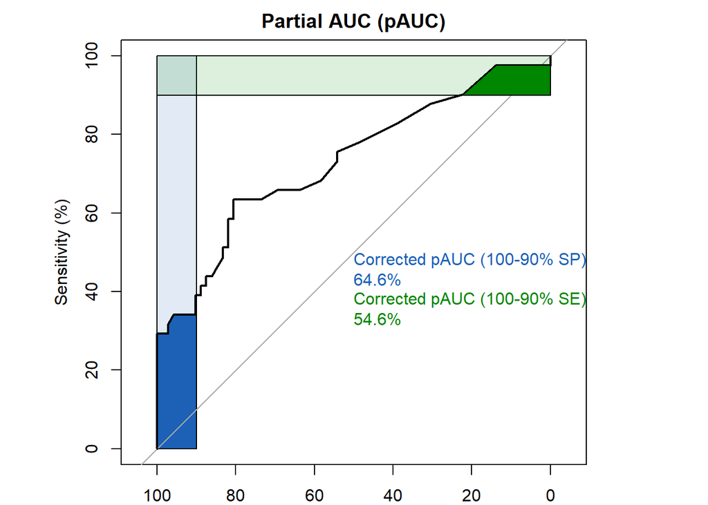

```r
plot.roc(aSAH$outcome, aSAH$s100b, # data
         mar=c(2, 6, 2, 6),
         percent=TRUE, # show all values in percent
         partial.auc=c(100, 90), partial.auc.correct=TRUE, # define a partial AUC (pAUC)
         print.auc=TRUE, #display pAUC value on the plot with following options:
         print.auc.pattern="Corrected pAUC (100-90%% SP):\n%.1f%%", print.auc.col="#1c61b6",
         auc.polygon=TRUE, auc.polygon.col="#1c61b6", # show pAUC as a polygon
         max.auc.polygon=TRUE, max.auc.polygon.col="#1c61b622", # also show the 100% polygon
         main="Partial AUC (pAUC)")
plot.roc(aSAH$outcome, aSAH$s100b,
         mar=c(2, 6, 2, 6),
         percent=TRUE, add=TRUE, type="n", # add to plot, but don't re-add the ROC itself (useless)
         partial.auc=c(100, 90), partial.auc.correct=TRUE,
         partial.auc.focus="se", # focus pAUC on the sensitivity
         print.auc=TRUE, print.auc.pattern="Corrected pAUC (100-90%% SE):\n%.1f%%", print.auc.col="#008600",
         print.auc.y=40, # do not print auc over the previous one
         auc.polygon=TRUE, auc.polygon.col="#008600",
         max.auc.polygon=TRUE, max.auc.polygon.col="#00860022")
```

**pROC funtion ggroc, based on ggplot2：**

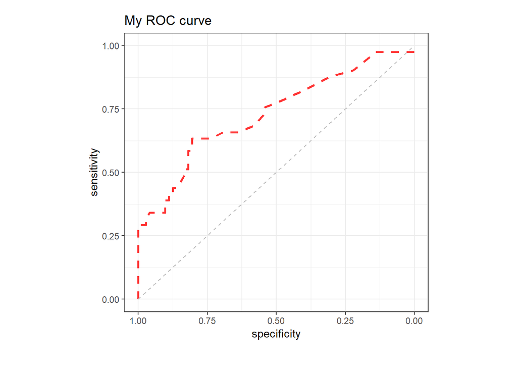

```r
library(ggplot2)
data(aSAH)
rocobj <- roc(aSAH$outcome, aSAH$s100b)
rocobj2 <- roc(aSAH$outcome, aSAH$wfns)
rocobj3 <- roc(aSAH$outcome, aSAH$ndka)

g <- ggroc(rocobj, alpha = 0.8, colour = "red", linetype = 2, size = 1)
g + theme_bw() + ggtitle("My ROC curve") +
  geom_segment(aes(x = 1, xend = 0, y = 0, yend = 1), color="grey", linetype="dashed") +
  theme(plot.margin=unit(c(1,6,2,6),'lines'))
```

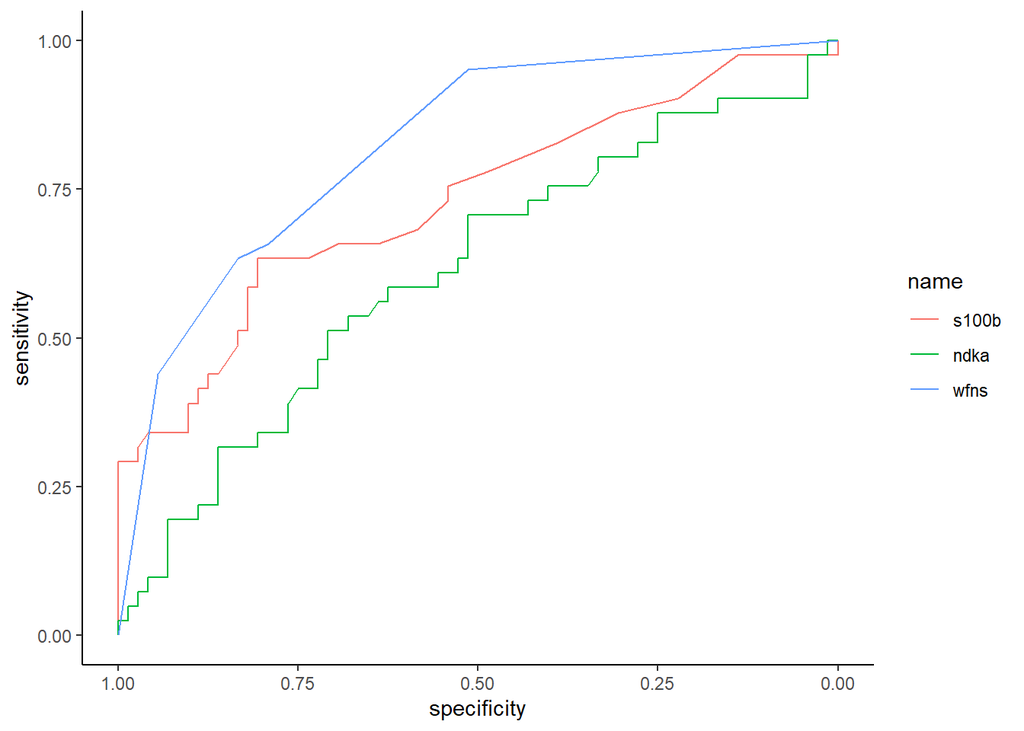

```r
# Multiple curves:
g.list <- ggroc(list(s100b=rocobj, wfns=rocobj2, ndka=rocobj3))

# This is equivalent to using roc.formula:
roc.list <- roc(outcome ~ s100b + ndka + wfns, data = aSAH)
g.list <- ggroc(roc.list)
g.list + theme_classic()
```

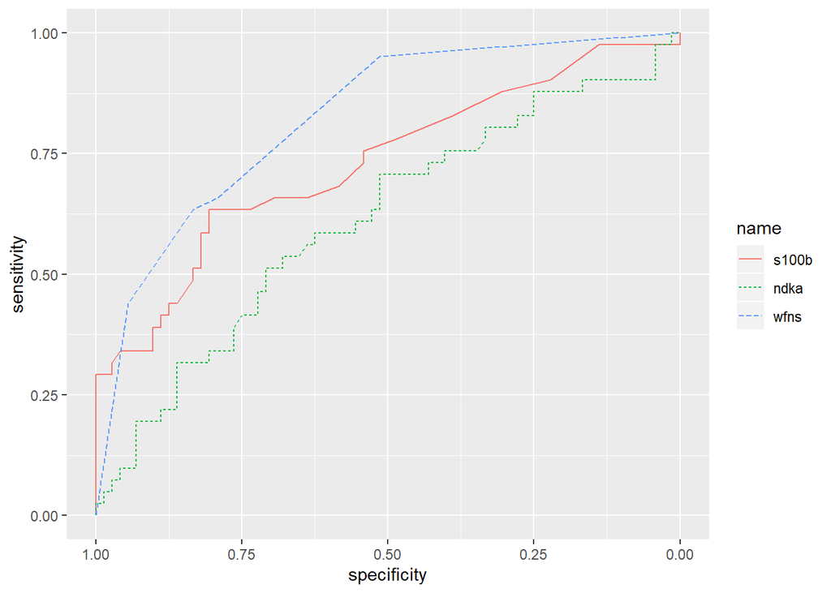

```r
# changing multiple aesthetics:
g5 <- ggroc(roc.list, aes=c("linetype", "color"))
g5
```

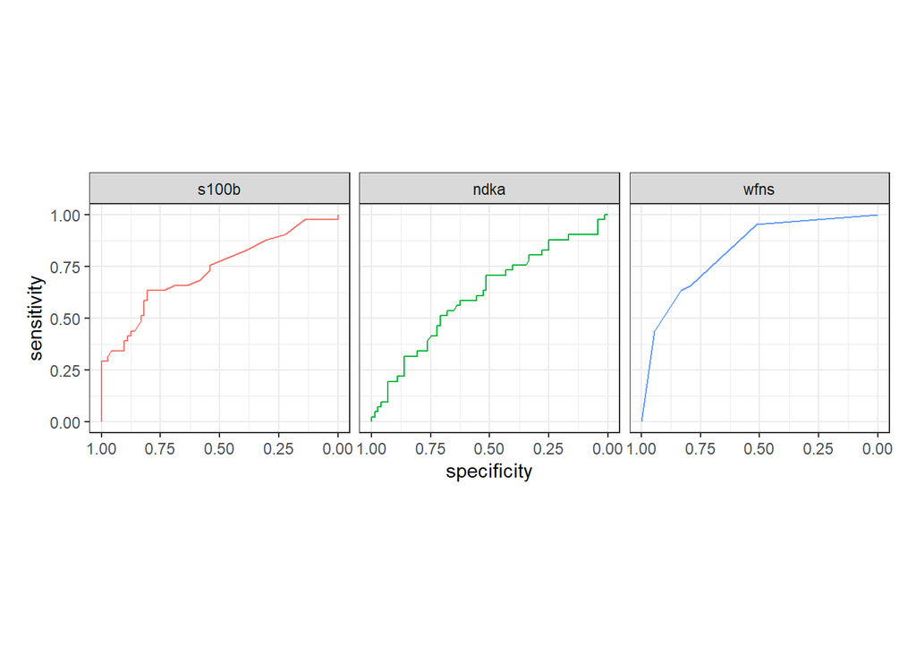

```r
# multiple facet
g.list + facet_grid(.~name) + theme_bw() +
  theme(legend.position="none",plot.margin=unit(c(6.6,1,6.6,1),'lines'))
```

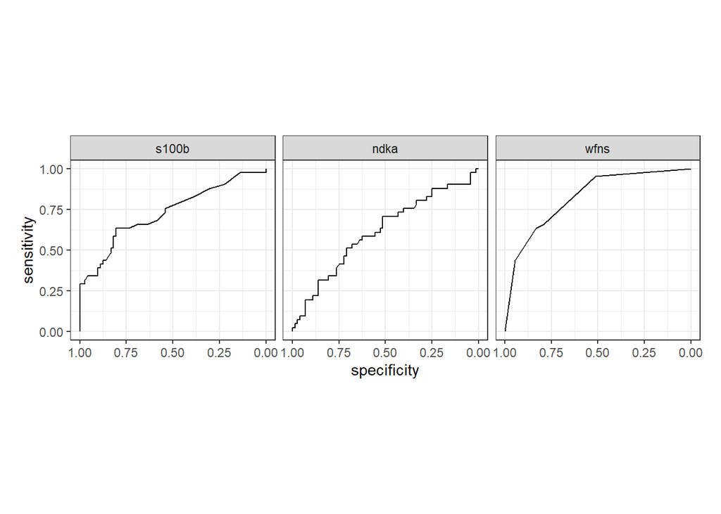

```r
# To have all the curves of the same color, use aes="group":
g.group <- ggroc(roc.list, aes="group")
g.group + facet_grid(.~name) + theme_bw()  +
  theme(plot.margin=unit(c(6.6,1,6.6,1),'lines'))
```

**plotROC, based on ggplot2：**

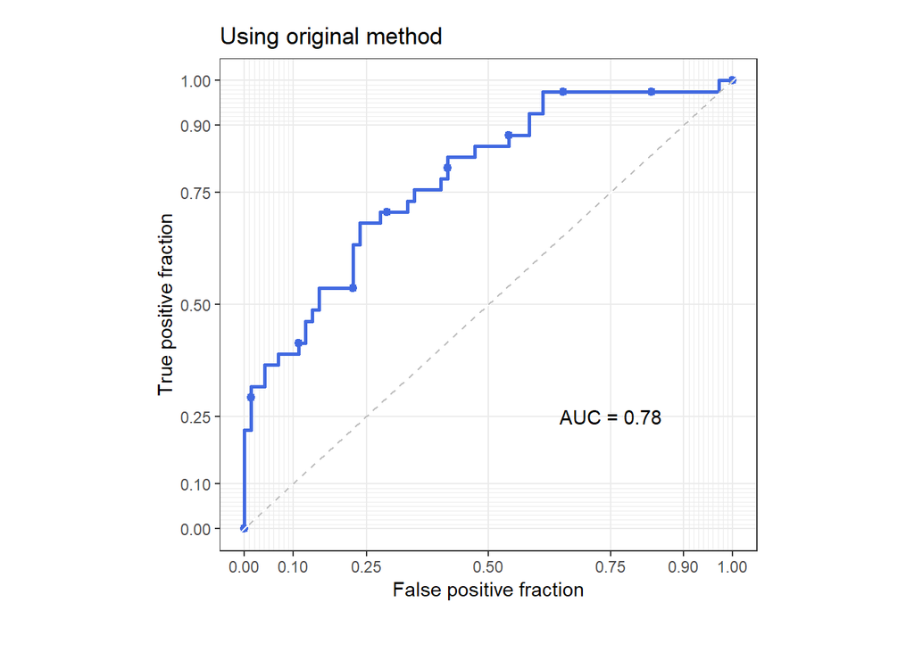

```r
library(ggplot2)
library(plotROC)
library(pROC) # load data aSAH
data(aSAH)
fit.model <- glm(outcome ~ s100b + ndka,
                 data=aSAH, family=binomial())
y_predict<-predict(fit.model,newdata=aSAH,type='response')
data_test <- data.frame(outcome=aSAH$outcome,model=y_predict,ndka=aSAH$ndka)

basic_plot <- ggplot(data_test, aes(d = outcome, m = model))+
  geom_roc(labels = FALSE,colour=my_colors[1])
basic_plot + style_roc() +
  annotate("text", x = .75, y = .25, ## position of text
           label = paste("AUC =", round(calc_auc(basic_plot)$AUC, 2))) +
  geom_segment(aes(x = 1, xend = 0, y = 1, yend = 0), color="grey", linetype="dashed")+
  ggtitle("Using original method") +
  theme(plot.margin=unit(c(1,6,2,6),'lines'))
```

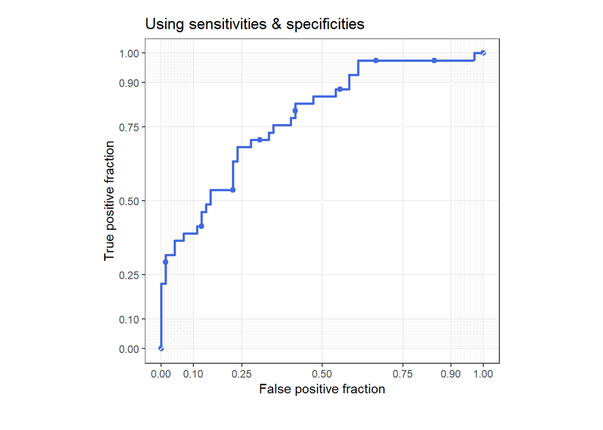

```r
roc_model<-roc(aSAH$outcome,y_predict)
data_roc<-data.frame(TPF = roc_model$sensitivities,
                     FPF = 1-roc_model$specificities,
                     c = roc_model$thresholds)
ggplot(data_roc, aes(x = FPF, y = TPF, label = c)) +
  geom_roc(stat = "identity",colour=my_colors[1],labels = FALSE) + style_roc()+
  ggtitle("Using sensitivities & specificities") +
  theme(plot.margin=unit(c(1,6,2,6),'lines'))
```

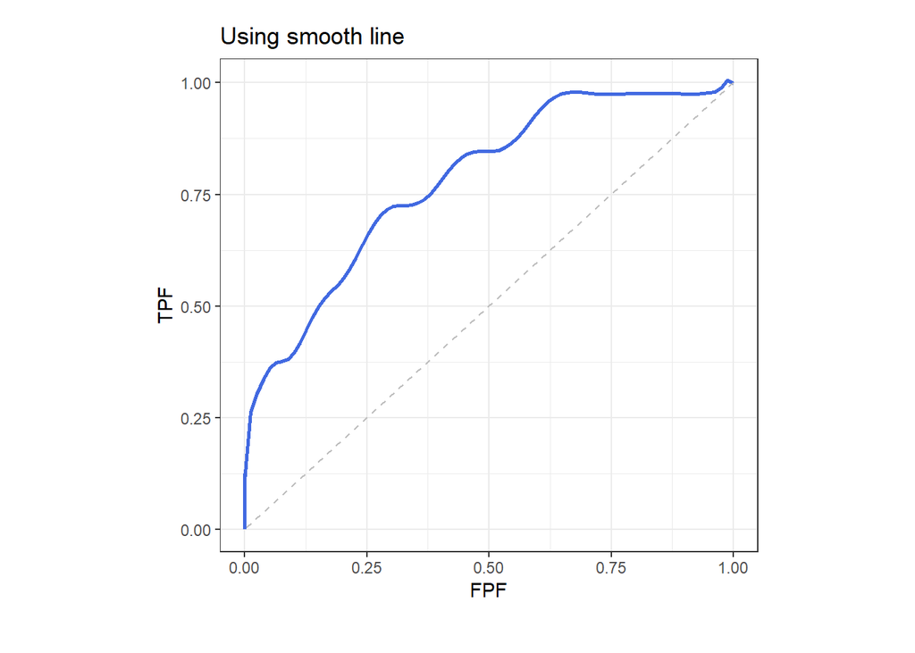

```r
ggplot(data_roc, aes(x = FPF, y = TPF, label = c)) +
  geom_smooth(method=lm, formula=y~poly(x,20),se=FALSE, color=my_colors[1], size=1)+
  geom_segment(aes(x = 0, xend = 0, y = 0, yend = 0.125), color=my_colors[1],size=1)+
  geom_segment(aes(x = 1, xend = 0, y = 1, yend = 0), color="grey", linetype="dashed")+
  ggtitle("Using smooth line") +
  theme_bw()+
  theme(plot.margin=unit(c(1,6,2,6),'lines'))
```

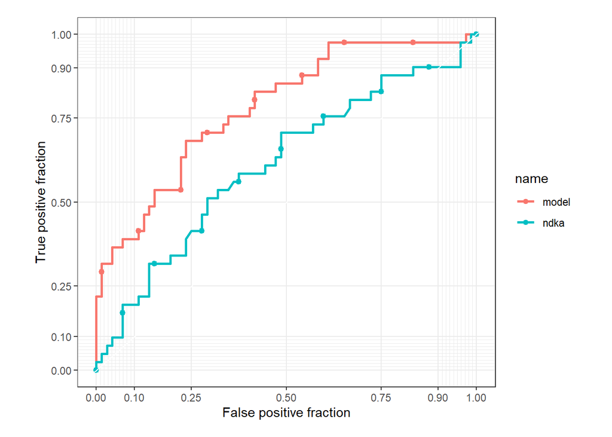

```r
# Mulitiple ROC
longtest <- melt_roc(data_test, "outcome", c("model", "ndka"))
ggplot(longtest, aes(d = D, m = M, color = name))+
  geom_roc(labels = FALSE) + style_roc() +
  theme(plot.margin=unit(c(1,2,1,2),'lines'))
```

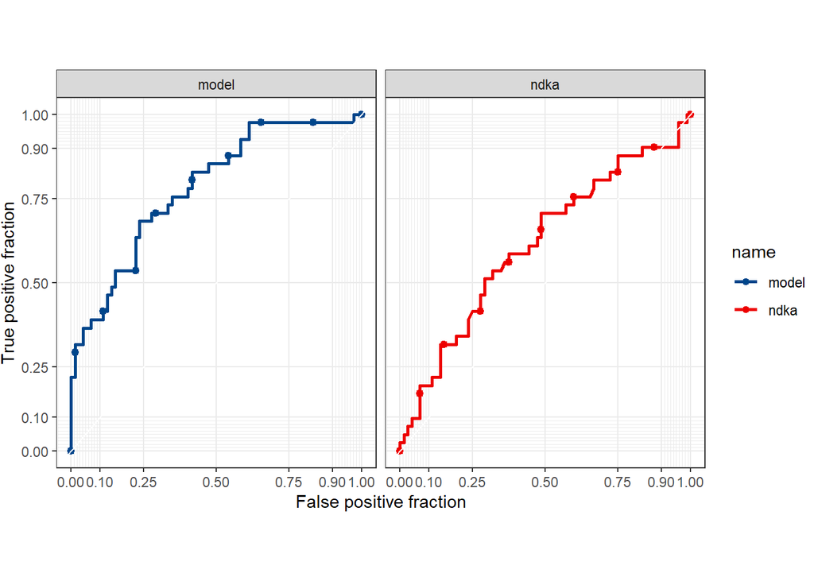

```r
ggplot(longtest, aes(d = D, m = M, color = name)) +
  geom_roc(labels = FALSE) +
  style_roc()+
  facet_wrap(~name)+
  ggsci::scale_color_lancet()+
  theme(plot.margin=unit(c(3,0,3,0),'lines'))
```

**plotROC, 交互式作图：**

```r
library(ggplot2)
library(plotROC)
library(pROC) # load data aSAH
data(aSAH)
fit.model <- glm(outcome ~ s100b + ndka,
                 data=aSAH, family=binomial())
y_predict<-predict(fit.model,newdata=aSAH,type='response')
data_test <- data.frame(outcome=aSAH$outcome,model=y_predict,ndka=aSAH$ndka)

basic_plot <- ggplot(data_test, aes(d = outcome, m = model))+
  geom_roc(labels = FALSE,colour=my_colors[1])
fine_plot <- basic_plot + style_roc() +
  annotate("text", x = .75, y = .25, ## position of text
           label = paste("AUC =", round(calc_auc(basic_plot)$AUC, 2))) +
  geom_segment(aes(x = 1, xend = 0, y = 1, yend = 0), color="grey", linetype="dashed")+
  ggtitle("Interactive Plots")
cat(
  export_interactive_roc(fine_plot,
                         prefix = "a")
)
```

[figure not shown]

## 生信

### 差异分析之limma

差异分析当然推荐limma流程，标准流程的输入数据为RNA-seq的counts矩阵或芯片数据。 如果从FPKM或TPM数据开始差异分析，需要进行些许改动（不推荐从FPKM等标准化数据开始分析）。 输入counts数据可以对数据进行voom处理（虽然不知道这种处理的优势在哪）。值得注意的是，常用的另外两个工具包edgeR和DESeq2都不支持FPKM等标准化后的数据作为输入，仅limma支持。

RNA-Seq的的limma分析标准流程示例：[R pipeline to analyze RNA-seq data](http://bioinf.wehi.edu.au/RNAseqCaseStudy/)和相应的[code](http://bioinf.wehi.edu.au/RNAseqCaseStudy/code.R)

```r
my_limma<-function(data,group_info,adjust.method="fdr",data_type="counts",
                   p.value.cutoff=1,fold.change.cutoff=1){
  require(dplyr)
  require(limma)
  require(edgeR)

  case_info_id<-tibble(case_id=colnames(data)[-1])
  case_info<-inner_join(case_info_id,group_info,by=c("case_id"=colnames(group_info)[1]))
  if (all(as.vector(unlist(group_info[,1]))!=colnames(data)[-1])){
    cat("Re-arranged!\n")
  }

  group_origin<-case_info[colnames(group_info)[2]] %>% unlist() %>% as.vector() %>% as.factor()
  group<-as.factor(paste("G",as.character(as.numeric(group_origin)),sep=""))
  design <- model.matrix(~ 0+group)
  colnames(design) <- levels(group)

  expr<-data[-1]
  gene_names<-data[,1] %>% unlist() %>% as.vector()
  if (length(gene_names)!=length(unique(gene_names))) { cat("Duplicate genes!\n") }
  expr_mat<-as.matrix(expr)
  row.names(expr_mat)<-gene_names

  # filter low expression
  data_med<-apply(expr_mat, 1, median)
  low_index<-which(data_med<0.001)
  expr_mat<-expr_mat[-low_index,]
  if (length(low_index)>0){
    cat("fitered low expression!\n")
  }

  # log2 transform
  ex <- expr_mat
  qx <- as.numeric(quantile(ex, c(0., 0.25, 0.5, 0.75, 0.99, 1.0), na.rm=T))
  LogC <- (qx[5] > 100) ||
    (qx[6]-qx[1] > 50 && qx[2] > 0) ||
    (qx[2] > 0 && qx[2] < 1 && qx[4] > 1 && qx[4] < 2)
  if (LogC) {
    ex[which(ex <= 0)] <- NaN
    expr_mat <- log2(ex)
    cat("log transforming...\n")
  }

  if (data_type=="counts"){
    cat("using method for counts...\n")
    # fit the model
    x <- DGEList(counts=expr_mat, genes=row.names(expr_mat))
    # perform voom normalization
    y <- voom(x,design,plot=TRUE)
    # cluster libraries
    # ? plotMDS(y,xlim=c(-2.5,2.5))
    # fit linear model and assess differential expression
    fit <- lmFit(y, design)

  }
  if (data_type %in% c("fpkm","tpm","rpkm")){
    cat("using method for FPKM/RPKM/TPM...\n")
    # fit the model
    fit <- lmFit(expr_mat, design)
  }
  if ((data_type %in% c("counts","fpkm","tpm","rpkm"))==FALSE){
    cat("data type not supported!\n")
    return(0)
  }
  cont.matrix <- makeContrasts(G2-G1, levels=design)
  fit2 <- contrasts.fit(fit, cont.matrix)
  fit2 <- eBayes(fit2)
  limma_results <- topTable(fit2,adjust.method=adjust.method,coef=1,p.value=p.value.cutoff,
                              lfc=log(fold.change.cutoff,2),number=50000,sort.by = 'logFC')
  return(as_tibble(limma_results,rownames="gene"))
}
```

注意事项  
**是否需要比较矩阵** 可参考这个讨论：[差异分析是否需要比较矩阵](https://github.com/bioconductor-china/basic/blob/master/makeContrasts.md)

```r
# method 1
library(CLL)
data(sCLLex)
library(limma)
design=model.matrix(~factor(sCLLex$Disease))
fit=lmFit(sCLLex,design)
fit=eBayes(fit)
options(digits = 4)
topTable(fit,coef=2,adjust='BH')
```

```
##            logFC AveExpr      t   P.Value adj.P.Val     B
## 39400_at  1.0285   5.621  5.836 8.341e-06   0.03344 3.234
## 36131_at -0.9888   9.954 -5.772 9.668e-06   0.03344 3.117
## 33791_at -1.8302   6.951 -5.736 1.049e-05   0.03344 3.052
## 1303_at   1.3836   4.463  5.732 1.060e-05   0.03344 3.044
## 36122_at -0.7801   7.260 -5.141 4.206e-05   0.10619 1.935
## 36939_at -2.5472   6.915 -5.038 5.362e-05   0.11283 1.737
## 41398_at  0.5187   7.602  4.879 7.824e-05   0.11520 1.428
## 32599_at  0.8544   5.746  4.859 8.207e-05   0.11520 1.389
## 36129_at  0.9161   8.209  4.859 8.212e-05   0.11520 1.389
## 37636_at -1.6868   5.697 -4.804 9.355e-05   0.11811 1.282
```

```r
# method 2
design=model.matrix(~0+factor(sCLLex$Disease))
colnames(design)=c('progres','stable')
fit=lmFit(sCLLex,design)
cont.matrix=makeContrasts('progres-stable',levels = design)
fit2=contrasts.fit(fit,cont.matrix)
fit2=eBayes(fit2)
options(digits = 4)
topTable(fit2,adjust='BH')
```

```
##            logFC AveExpr      t   P.Value adj.P.Val     B
## 39400_at -1.0285   5.621 -5.836 8.341e-06   0.03344 3.234
## 36131_at  0.9888   9.954  5.772 9.668e-06   0.03344 3.117
## 33791_at  1.8302   6.951  5.736 1.049e-05   0.03344 3.052
## 1303_at  -1.3836   4.463 -5.732 1.060e-05   0.03344 3.044
## 36122_at  0.7801   7.260  5.141 4.206e-05   0.10619 1.935
## 36939_at  2.5472   6.915  5.038 5.362e-05   0.11283 1.737
## 41398_at -0.5187   7.602 -4.879 7.824e-05   0.11520 1.428
## 32599_at -0.8544   5.746 -4.859 8.207e-05   0.11520 1.389
## 36129_at -0.9161   8.209 -4.859 8.212e-05   0.11520 1.389
## 37636_at  1.6868   5.697  4.804 9.355e-05   0.11811 1.282
```

### 差异分析之edgeR

官方文档中明确指出，edgeR仅支持RNA-Seq原始的counts数据，不支持标准化处理后的数据（如FPKM/RPKM/TPM等），略微兼容RSEM数据，但是不推荐。具体介绍请参考：edgeRUsersGuide()。如下为封装的代码函数（暂时未进行测试，慎用）。

```r
my_edgeR<-function(){
  require(dplyr)
  require(edgeR)

  case_info_id<-tibble(case_id=colnames(data)[-1])
  case_info<-inner_join(case_info_id,group_info,by=c("case_id"=colnames(group_info)[1]))
  if (paste(as.vector(unlist(group_info[,1])),collapse = "")!=
      paste(colnames(data)[-1],collapse = "")){
    cat("grouping...\n")
  }

  group_origin<-case_info[colnames(group_info)[2]] %>% unlist() %>% as.vector() %>% as.factor()
  group<-as.factor(paste("G",as.character(as.numeric(group_origin)),sep=""))

  expr<-data[-1]
  gene_names<-data[,1] %>% unlist() %>% as.vector()
  if (length(gene_names)!=length(unique(gene_names))) { cat("Duplicate genes!\n") }
  expr_mat<-as.matrix(expr)
  row.names(expr_mat)<-gene_names

  # main code
  y <- DGEList(counts=expr_mat,group=group)
  y <- calcNormFactors(y) # default method is TMM
  y <- estimateCommonDisp(y)
  y <- estimateTagwiseDisp(y)
  et <- exactTest(y,pair = levels(group))
  ordered_tags <- topTags(et, n=100000)
  temp <- ordered_tags$table
  edgeR_results = temp[is.na(temp$FDR)==FALSE,]
}
```

### 差异表达分析之DESeq2

官方文档中明确指出，DESeq2的表达数据需为原始counts数据，不支持FPKM等标准化后的数据。HT-seq的count是可以的，请参考文档：Rstudio的help处搜索DESeq2。如下为代码示例

```r
library("pasilla")
pasCts <- system.file("extdata",
                      "pasilla_gene_counts.tsv",
                      package="pasilla", mustWork=TRUE)
pasAnno <- system.file("extdata",
                       "pasilla_sample_annotation.csv",
                       package="pasilla", mustWork=TRUE)
cts <- as.matrix(read.csv(pasCts,sep="\t",row.names="gene_id"))
coldata <- read.csv(pasAnno, row.names=1)
coldata <- coldata[,c("condition","type")]
rownames(coldata) <- sub("fb", "", rownames(coldata))
# all(rownames(coldata) %in% colnames(cts))
## [1] TRUE
# all(rownames(coldata) == colnames(cts))
## [1] FALSE
cts <- cts[, rownames(coldata)]
# all(rownames(coldata) == colnames(cts))
## [1] TRUE
library("DESeq2")
dds <- DESeqDataSetFromMatrix(countData = cts,
                              colData = coldata,
                              design = ~ condition)
dds <- DESeq(dds)
res <- results(dds)
resOrdered <- res[order(res$pvalue),]
sum(res$padj < 0.1, na.rm=TRUE)
```

```
## [1] 1061
```

```r
res.df<-as.data.frame(res)
head(res.df)
```

```
##                 baseMean log2FoldChange     lfcSE         stat    pvalue
## FBgn0000003    0.1715687   -1.026045410 3.8055034 -0.269621465 0.7874515
## FBgn0000008   95.1440790   -0.002151424 0.2238838 -0.009609555 0.9923328
## FBgn0000014    1.0565722    0.496735569 2.1602643  0.229942039 0.8181368
## FBgn0000015    0.8467233    1.882761702 2.1064322  0.893815463 0.3714206
## FBgn0000017 4352.5928988    0.240025230 0.1260243  1.904594503 0.0568328
## FBgn0000018  418.6149305    0.104799112 0.1482803  0.706763605 0.4797134
##                  padj
## FBgn0000003        NA
## FBgn0000008 0.9969271
## FBgn0000014        NA
## FBgn0000015        NA
## FBgn0000017 0.2823611
## FBgn0000018 0.8239073
```

### 火山图

**简单火山图**

```r
my_simple_volcanoPlot<-function(logFC, pvalue, logFC.cutoff=1, pvalue.cutoff=0.05,
                                xlab="Log2(Fold change)", ylab="-Log10(Pvalue)",
                                main="",xlim=NULL,ylim=NULL){

  if (is.null(xlim)) xlim<-max(abs(logFC))
  if (is.null(ylim)) ylim<-max(-log10(pvalue))
  data<-tibble(logFC=logFC, pvalue=pvalue,
               DEG=rep('notDEG',length(logFC)),
               colors=rep('grey',length(logFC)))
  # set colors
  data$DEG[data$logFC > logFC.cutoff & data$pvalue < pvalue.cutoff] = 'Up'
  data$DEG[data$logFC < -logFC.cutoff & data$pvalue < pvalue.cutoff] = 'Down'
  data$colors = factor(data$DEG,levels=c("Down","notDEG","Up"),
                       labels=c("darkgreen","grey","red"))

  # draw scatter plot
  plot(data$logFC, -log10(data$pvalue), pch=16,
       col=as.character(data$colors),
       xlab=xlab, ylab=ylab, cex=0.5, main=main, xlim=c(-xlim,xlim),ylim=c(0,ylim))
  abline(h=-log(pvalue.cutoff,10),col="black",lwd=1)
  abline(v=c(logFC.cutoff,-logFC.cutoff),col="black",lwd=1)
}
```